# Replication of College Football Games and Crime

Group 6

```r
library(tidyverse)
library(lubridate)
library(knitr)
```

# Introduction

This project replicates and extends Rees and Schnepel’s study on whether college football games are associated with increases in crime in host communities. We focus on daily assault and vandalism counts from NIBRS and match them to college football schedules from 2000 to 2005.

# Descriptive Statistics

## Table 1: Appendix

```r
analysis_data <- read_csv(
  "data/processed/analysis_data.csv",
  show_col_types = FALSE
)

analysis_data_clean <- analysis_data %>%
  filter(
    !team %in% c(
      "Ohio State",
      "Texas Tech",
      "South Carolina"
    )
  )

appendix_long <- analysis_data_clean %>%
  mutate(
    game_type = case_when(
      home_game == 1 ~ "Home Game",
      away_game == 1 ~ "Away Game",
      TRUE ~ "No Game"
    )
  ) %>%
  pivot_longer(
    cols = c(assault, vandalism),
    names_to = "crime_type",
    values_to = "count"
  )

appendix_table1 <- bind_rows(
  appendix_long %>% mutate(game_type = "All Days"),
  appendix_long
) %>%
  group_by(crime_type, game_type) %>%
  summarise(
    mean_sd = paste0(round(mean(count), 2), " (", round(sd(count), 2), ")"),
    q25 = as.character(quantile(count, 0.25)),
    q50 = as.character(quantile(count, 0.50)),
    q75 = as.character(quantile(count, 0.75)),
    q90 = as.character(quantile(count, 0.90)),
    .groups = "drop"
  ) %>%
  pivot_longer(
    cols = c(mean_sd, q25, q50, q75, q90),
    names_to = "stat",
    values_to = "value"
  ) %>%
  mutate(
    stat = recode(
      stat,
      mean_sd = "",
      q25 = "0.25 quantile",
      q50 = "0.50 quantile",
      q75 = "0.75 quantile",
      q90 = "0.90 quantile"
    ),
    game_type = factor(
      game_type,
      levels = c("All Days", "No Game", "Home Game", "Away Game")
    ),
    crime_type = recode(
      crime_type,
      assault = "Assaults",
      vandalism = "Vandalism"
    )
  ) %>%
  arrange(crime_type, stat, game_type) %>%
  pivot_wider(
    names_from = game_type,
    values_from = value
  ) %>%
  select(
    crime_type,
    stat,
    `All Days`,
    `No Game`,
    `Home Game`,
    `Away Game`
  )

knitr::kable(
  appendix_table1,
  col.names = c("", "", "All Days", "No Game", "Home Game", "Away Game")
)
```

|  |  | All Days | No Game | Home Game | Away Game |
| --- | --- | --- | --- | --- | --- |
| Assaults |  | 3.74 (7.24) | 3.68 (7.13) | 4.46 (8.46) | 4.54 (8.33) |
| Assaults | 0.25 quantile | 0 | 0 | 0 | 0 |
| Assaults | 0.50 quantile | 1 | 1 | 2 | 1 |
| Assaults | 0.75 quantile | 4 | 4 | 5 | 5 |
| Assaults | 0.90 quantile | 10 | 9 | 10.6 | 12 |
| Vandalism |  | 3.69 (6.09) | 3.59 (5.96) | 5.01 (7.41) | 4.77 (7.4) |
| Vandalism | 0.25 quantile | 0 | 0 | 0 | 0 |
| Vandalism | 0.50 quantile | 2 | 1 | 3 | 2 |
| Vandalism | 0.75 quantile | 4 | 4 | 6 | 5 |
| Vandalism | 0.90 quantile | 10 | 10 | 13.6 | 14 |

## Table 2: Distribution of Game Days by Day of the Week

```r
table2 <-
  analysis_data %>%
  mutate(game = 1-no_game) %>%
  group_by(game, day_of_week) %>%
  summarize(count = n()) %>%
  pivot_wider(names_from = game, values_from = count) %>%
  mutate(observation_days = `1`) %>%
  replace_na(replace = list(observation_days = 0)) %>%
  mutate(agency_days = `0` + observation_days) %>%
  select(day_of_week, observation_days, agency_days)
```

[output not shown]

```r
table2_with_totals <-
  table2 %>%
  add_row(day_of_week = "Total", agency_days = sum(table2$agency_days), observation_days = sum(table2$observation_days))


knitr::kable(
  table2_with_totals,
  col.names = c("Day of Week", "Games", "Observations")
)
```

| Day of Week | Games | Observations |
| --- | --- | --- |
| Fri | 53 | 3432 |
| Mon | 0 | 3406 |
| Sat | 1474 | 3406 |
| Sun | 192 | 3406 |
| Thu | 58 | 3406 |
| Tue | 2 | 3406 |
| Wed | 11 | 3406 |
| Total | 1790 | 23868 |

# Descriptive Figures

```r
saturday_summary <- analysis_data %>%
  filter(day_of_week == "Sat") %>%
  mutate(
    game_type = case_when(
      home_game == 1 ~ "Home Game",
      away_game == 1 ~ "Away Game",
      TRUE ~ "No Game"
    )
  ) %>%
  group_by(game_type) %>%
  summarise(
    mean_assault = mean(assault),
    se_assault = sd(assault) / sqrt(n()),
    mean_vandalism = mean(vandalism),
    se_vandalism = sd(vandalism) / sqrt(n()),
    .groups = "drop"
  )

knitr::kable(saturday_summary)
```

| game_type | mean_assault | se_assault | mean_vandalism | se_vandalism |
| --- | --- | --- | --- | --- |
| Away Game | 4.413295 | 0.3032046 | 4.424855 | 0.2793135 |
| Home Game | 4.179028 | 0.2865396 | 4.457801 | 0.2590029 |
| No Game | 4.164079 | 0.1848333 | 3.861801 | 0.1563518 |

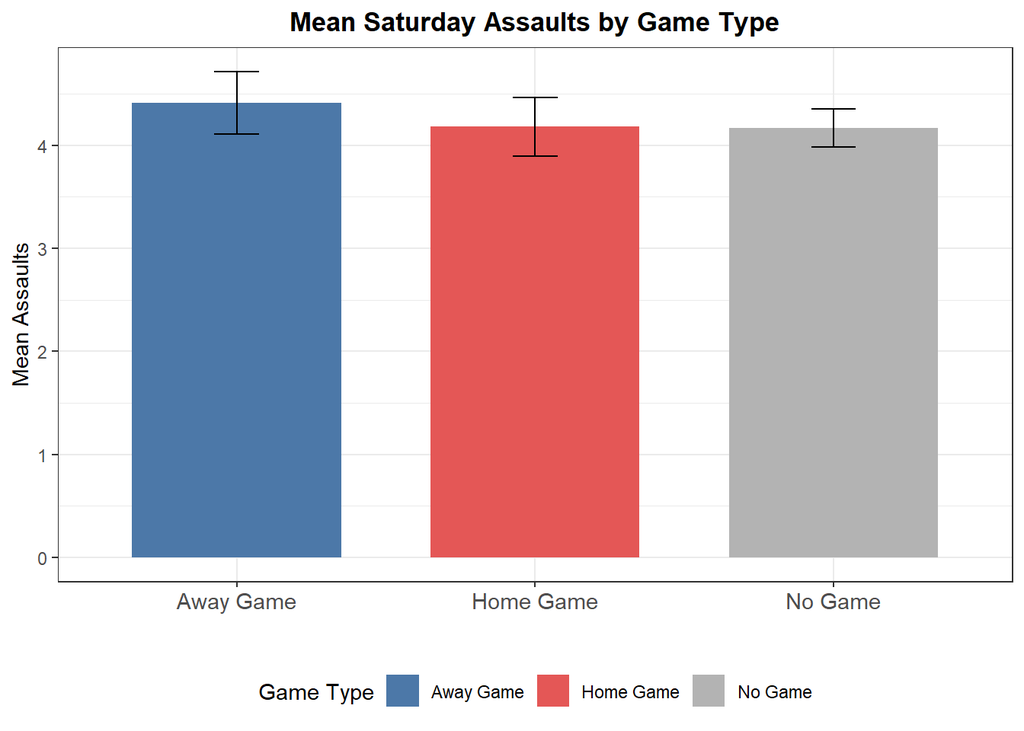

```r
ggplot(
  saturday_summary,
  aes(x = game_type, y = mean_assault, fill = game_type)
) +
  geom_col(width = 0.7) +
  geom_errorbar(
    aes(
      ymin = mean_assault - se_assault,
      ymax = mean_assault + se_assault
    ),
    width = 0.15
  ) +
  scale_fill_manual(
    values = c(
      "No Game" = "gray70",
      "Away Game" = "#4C78A8",
      "Home Game" = "#E45756"
    )
  ) +
  labs(
    title = "Mean Saturday Assaults by Game Type",
    x = "",
    y = "Mean Assaults",
    fill = "Game Type"
  ) +
  theme_bw() +
  theme(
    plot.title = element_text(hjust = 0.5, face = "bold"),
    legend.position = "bottom",
    axis.text.x = element_text(size = 11)
  )
```

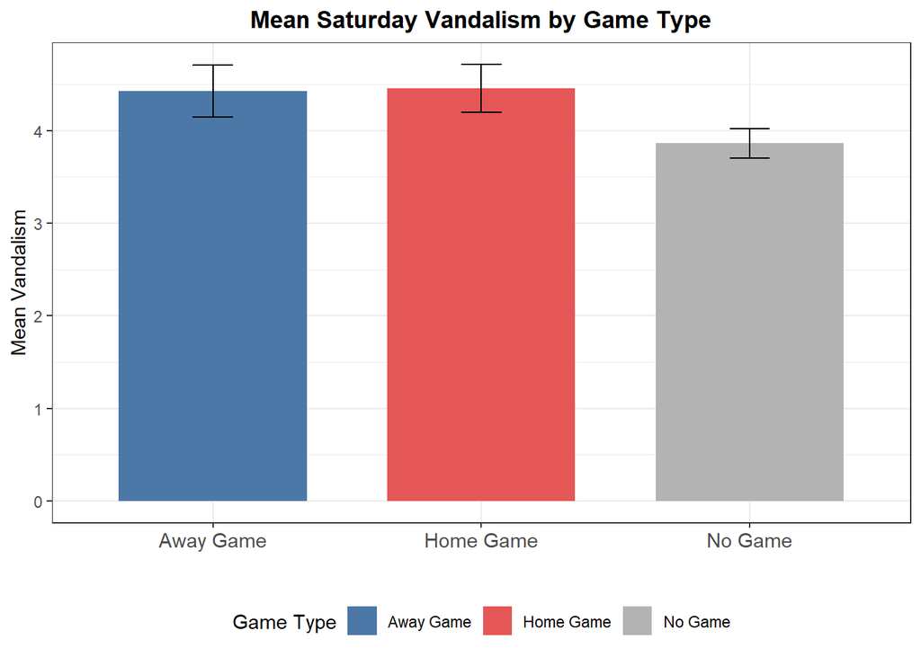

```r
ggplot(
  saturday_summary,
  aes(x = game_type, y = mean_vandalism, fill = game_type)
) +
  geom_col(width = 0.7) +
  geom_errorbar(
    aes(
      ymin = mean_vandalism - se_vandalism,
      ymax = mean_vandalism + se_vandalism
    ),
    width = 0.15
  ) +
  scale_fill_manual(
    values = c(
      "No Game" = "gray70",
      "Away Game" = "#4C78A8",
      "Home Game" = "#E45756"
    )
  ) +
  labs(
    title = "Mean Saturday Vandalism by Game Type",
    x = "",
    y = "Mean Vandalism",
    fill = "Game Type"
  ) +
  theme_bw() +
  theme(
    plot.title = element_text(hjust = 0.5, face = "bold"),
    legend.position = "bottom",
    axis.text.x = element_text(size = 11)
  )
```

# Per-Team Plots

```r
team_summary <- analysis_data %>%
  filter(day_of_week == "Sat") %>%
  mutate(
    game_type = case_when(
      home_game == 1 ~ "Home Game",
      away_game == 1 ~ "Away Game",
      TRUE ~ "No Game"
    ),
    game_type = factor(
      game_type,
      levels = c("No Game", "Away Game", "Home Game")
    )
  ) %>%
  group_by(team, game_type) %>%
  summarise(
    mean_assault = mean(assault),
    mean_vandalism = mean(vandalism),
    .groups = "drop")
```

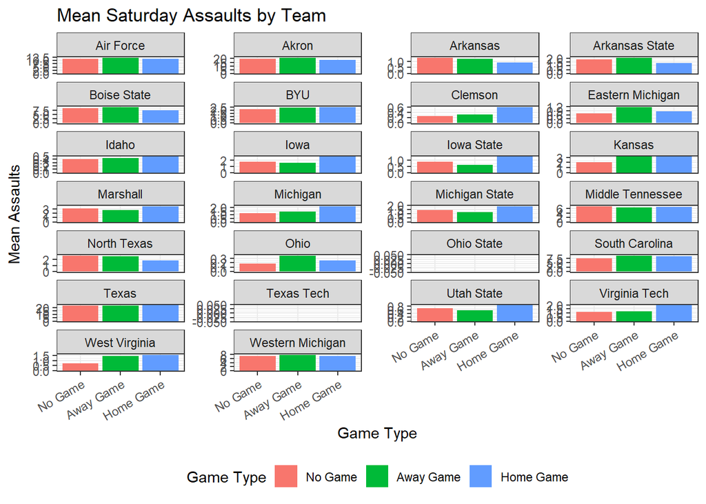

```r
ggplot(
  team_summary,
  aes(x = game_type, y = mean_assault, fill = game_type)
) +
  geom_col() +
  facet_wrap(~team, ncol = 4, scales = "free_y") +
  labs(
    title = "Mean Saturday Assaults by Team",
    x = "Game Type",
    y = "Mean Assaults",
    fill = "Game Type"
  ) +
  theme_bw() +
  theme(
    axis.text.x = element_text(angle = 30, hjust = 1),
    legend.position = "bottom"
  )
```

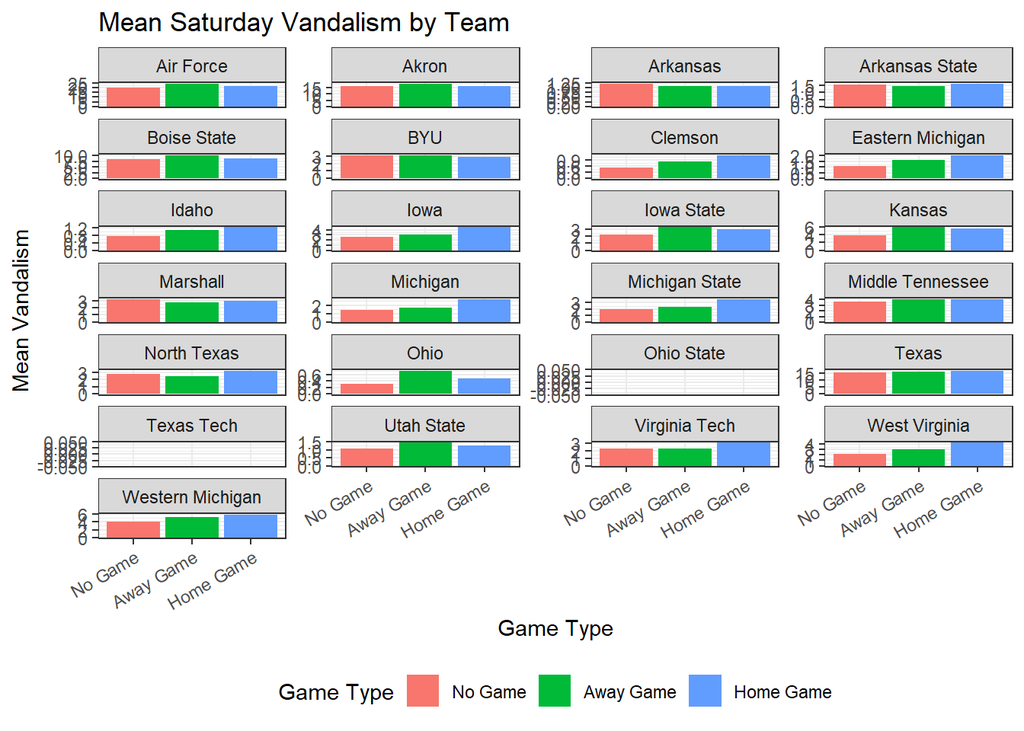

```r
ggplot(
  filter(team_summary, team != "South Carolina"),
  aes(x = game_type, y = mean_vandalism, fill = game_type)
) +
  geom_col() +
  facet_wrap(~team, ncol = 4, scales = "free_y") +
  labs(
    title = "Mean Saturday Vandalism by Team",
    x = "Game Type",
    y = "Mean Vandalism",
    fill = "Game Type"
  ) +
  theme_bw() +
  theme(
    axis.text.x = element_text(angle = 30, hjust = 1),
    legend.position = "bottom"
  )
```

# Regression Results

```r
assault_model <-
  lm(analysis_data$assault ~ as.factor(ori) + as.factor(day_of_week) + month + year + away_game + home_game, data=analysis_data)

summary(assault_model)
```

```
##
## Call:
## lm(formula = analysis_data$assault ~ as.factor(ori) + as.factor(day_of_week) +
##     month + year + away_game + home_game, data = analysis_data)
##
## Residuals:
##     Min      1Q  Median      3Q     Max
## -19.818  -1.042  -0.133   0.887  50.167
##
## Coefficients:
##                            Estimate Std. Error t value Pr(>|t|)
## (Intercept)               128.63974   36.40063   3.534 0.000410 ***
## as.factor(ori)AR0720100    -0.45692    0.22386  -2.041 0.041255 *
## as.factor(ori)CO0210100     7.95507    0.22385  35.537  < 2e-16 ***
## as.factor(ori)IA0520200    -0.15822    0.22385  -0.707 0.479686
## as.factor(ori)IA0850100    -0.91754    0.22385  -4.099 4.17e-05 ***
## as.factor(ori)ID0010100     5.57028    0.22385  24.884  < 2e-16 ***
## as.factor(ori)ID0290500    -1.30904    0.22385  -5.848 5.05e-09 ***
## as.factor(ori)KS0230100     0.56086    0.22386   2.505 0.012236 *
## as.factor(ori)MI3336400    -0.56569    0.22385  -2.527 0.011510 *
## as.factor(ori)MI3759900    -0.84306    0.22385  -3.766 0.000166 ***
## as.factor(ori)MI3949900     5.31287    0.22385  23.734  < 2e-16 ***
## as.factor(ori)MI8121800    -0.49797    0.22386  -2.224 0.026125 *
## as.factor(ori)OH0050100    -1.41147    0.22385  -6.305 2.92e-10 ***
## as.factor(ori)OH0250100    -1.58867    0.22386  -7.097 1.31e-12 ***
## as.factor(ori)OH0770100    16.92168    0.22385  75.594  < 2e-16 ***
## as.factor(ori)SC0390200    -1.37378    0.22386  -6.137 8.55e-10 ***
## as.factor(ori)SC0400100     4.90067    0.22386  21.892  < 2e-16 ***
## as.factor(ori)TN0750100     3.83580    0.22385  17.136  < 2e-16 ***
## as.factor(ori)TX0610200     0.73346    0.22385   3.277 0.001052 **
## as.factor(ori)TX1520200    -1.58869    0.22385  -7.097 1.31e-12 ***
## as.factor(ori)TX2270100    17.16948    0.22385  76.700  < 2e-16 ***
## as.factor(ori)UT0030100    -1.06805    0.22385  -4.771 1.84e-06 ***
## as.factor(ori)UT0250600     0.43956    0.22385   1.964 0.049585 *
## as.factor(ori)VA0600100    -0.71975    0.22386  -3.215 0.001305 **
## as.factor(ori)WV0060200     1.13175    0.22385   5.056 4.32e-07 ***
## as.factor(ori)WV0310100    -0.80292    0.22385  -3.587 0.000335 ***
## as.factor(day_of_week)Mon  -0.43213    0.11601  -3.725 0.000196 ***
## as.factor(day_of_week)Sat   0.50307    0.13029   3.861 0.000113 ***
## as.factor(day_of_week)Sun   0.45259    0.11614   3.897 9.77e-05 ***
## as.factor(day_of_week)Thu  -0.33428    0.11599  -2.882 0.003956 **
## as.factor(day_of_week)Tue  -0.38665    0.11601  -3.333 0.000861 ***
## as.factor(day_of_week)Wed  -0.42549    0.11601  -3.668 0.000245 ***
## month                      -0.17373    0.02189  -7.938 2.15e-15 ***
## year                       -0.06254    0.01818  -3.441 0.000581 ***
## away_game                   0.16735    0.18438   0.908 0.364069
## home_game                   0.21726    0.17946   1.211 0.226053
## ---
## Signif. codes:  0 '***' 0.001 '**' 0.01 '*' 0.05 '.' 0.1 ' ' 1
##
## Residual standard error: 4.796 on 23832 degrees of freedom
## Multiple R-squared:  0.527,  Adjusted R-squared:  0.5263
## F-statistic: 758.7 on 35 and 23832 DF,  p-value: < 2.2e-16
```

```r
mean(analysis_data$assault)
```

```
## [1] 3.55874
```

```r
# Divide home_game coefficient by mean_assaults to get percent increase

vandalism_model <-
  lm(analysis_data$vandalism ~ as.factor(ori) + as.factor(day_of_week) + month + year + away_game + home_game, data=analysis_data)

summary(vandalism_model)
```

```
##
## Call:
## lm(formula = analysis_data$vandalism ~ as.factor(ori) + as.factor(day_of_week) +
##     month + year + away_game + home_game, data = analysis_data)
##
## Residuals:
##     Min      1Q  Median      3Q     Max
## -15.113  -1.265  -0.230   0.857  68.474
##
## Coefficients:
##                           Estimate Std. Error t value Pr(>|t|)
## (Intercept)               42.88358   30.15546   1.422 0.155015
## as.factor(ori)AR0720100   -0.43516    0.18545  -2.346 0.018962 *
## as.factor(ori)CO0210100   14.78560    0.18545  79.729  < 2e-16 ***
## as.factor(ori)IA0520200    0.88255    0.18545   4.759 1.96e-06 ***
## as.factor(ori)IA0850100    0.54359    0.18545   2.931 0.003379 **
## as.factor(ori)ID0010100    5.17068    0.18545  27.883  < 2e-16 ***
## as.factor(ori)ID0290500   -0.74076    0.18545  -3.994 6.50e-05 ***
## as.factor(ori)KS0230100    2.00047    0.18545  10.787  < 2e-16 ***
## as.factor(ori)MI3336400    0.22551    0.18545   1.216 0.223988
## as.factor(ori)MI3759900   -0.40078    0.18545  -2.161 0.030693 *
## as.factor(ori)MI3949900    2.79475    0.18544  15.071  < 2e-16 ***
## as.factor(ori)MI8121800   -0.25661    0.18545  -1.384 0.166456
## as.factor(ori)OH0050100   -1.24538    0.18544  -6.716 1.91e-11 ***
## as.factor(ori)OH0250100   -1.49380    0.18545  -8.055 8.32e-16 ***
## as.factor(ori)OH0770100   12.21495    0.18545  65.868  < 2e-16 ***
## as.factor(ori)SC0390200   -1.05509    0.18545  -5.689 1.29e-08 ***
## as.factor(ori)SC0400100   -1.49317    0.18545  -8.052 8.55e-16 ***
## as.factor(ori)TN0750100    1.71758    0.18544   9.262  < 2e-16 ***
## as.factor(ori)TX0610200    0.62844    0.18545   3.389 0.000703 ***
## as.factor(ori)TX1520200   -1.49372    0.18545  -8.055 8.34e-16 ***
## as.factor(ori)TX2270100   11.29169    0.18545  60.889  < 2e-16 ***
## as.factor(ori)UT0030100   -0.58662    0.18545  -3.163 0.001562 **
## as.factor(ori)UT0250600    0.98331    0.18545   5.302 1.15e-07 ***
## as.factor(ori)VA0600100    0.03798    0.18545   0.205 0.837736
## as.factor(ori)WV0060200    1.33751    0.18544   7.212 5.66e-13 ***
## as.factor(ori)WV0310100    0.59215    0.18545   3.193 0.001409 **
## as.factor(day_of_week)Mon -0.78057    0.09611  -8.122 4.82e-16 ***
## as.factor(day_of_week)Sat  0.15215    0.10793   1.410 0.158659
## as.factor(day_of_week)Sun -0.30766    0.09622  -3.198 0.001388 **
## as.factor(day_of_week)Thu -0.86303    0.09609  -8.981  < 2e-16 ***
## as.factor(day_of_week)Tue -0.96410    0.09611 -10.031  < 2e-16 ***
## as.factor(day_of_week)Wed -0.89208    0.09610  -9.283  < 2e-16 ***
## month                     -0.14298    0.01813  -7.886 3.25e-15 ***
## year                      -0.01971    0.01506  -1.309 0.190498
## away_game                  0.41306    0.15275   2.704 0.006852 **
## home_game                  0.57673    0.14867   3.879 0.000105 ***
## ---
## Signif. codes:  0 '***' 0.001 '**' 0.01 '*' 0.05 '.' 0.1 ' ' 1
##
## Residual standard error: 3.973 on 23832 degrees of freedom
## Multiple R-squared:  0.5385, Adjusted R-squared:  0.5378
## F-statistic: 794.6 on 35 and 23832 DF,  p-value: < 2.2e-16
```

```r
mean(analysis_data$vandalism)
```

```
## [1] 3.262276
```

```r
# Divide home_game coefficient by mean_vandalism to get percent increase
```

# Extensions

## Extension: Home Wins versus Home Losses

```r
win_loss_summary <- analysis_data %>%
  filter(home_game == 1) %>%
  mutate(
    outcome = ifelse(home_win, "Win", "Loss")
  ) %>%
  group_by(outcome) %>%
  summarise(
    mean_assault = mean(assault),
    se_assault = sd(assault) / sqrt(n()),
    mean_vandalism = mean(vandalism),
    se_vandalism = sd(vandalism) / sqrt(n()),
    .groups = "drop"
  )

knitr::kable(win_loss_summary)
```

| outcome | mean_assault | se_assault | mean_vandalism | se_vandalism |
| --- | --- | --- | --- | --- |
| Loss | 3.620000 | 0.3807035 | 3.973333 | 0.3704495 |
| Win | 4.561514 | 0.3501927 | 4.566246 | 0.2952308 |

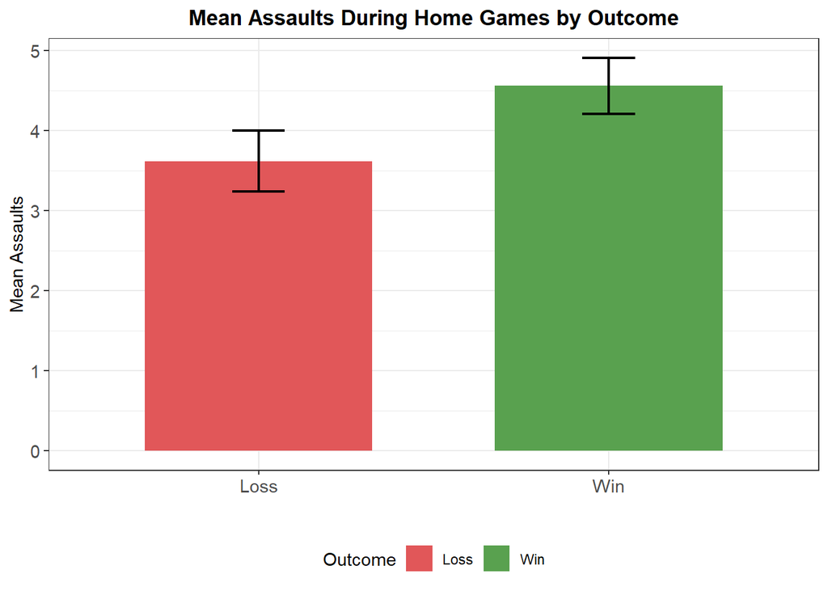

```r
ggplot(
  win_loss_summary,
  aes(x = outcome, y = mean_assault, fill = outcome)
) +
  geom_col(width = 0.65) +
  geom_errorbar(
    aes(
      ymin = mean_assault - se_assault,
      ymax = mean_assault + se_assault
    ),
    width = 0.15,
    linewidth = 0.8
  ) +
  scale_fill_manual(
    values = c(
      "Win" = "#59A14F",
      "Loss" = "#E15759"
    )
  ) +
  labs(
    title = "Mean Assaults During Home Games by Outcome",
    x = "",
    y = "Mean Assaults",
    fill = "Outcome"
  ) +
  theme_bw() +
  theme(
    plot.title = element_text(hjust = 0.5, face = "bold"),
    legend.position = "bottom",
    axis.text = element_text(size = 11)
  )
```

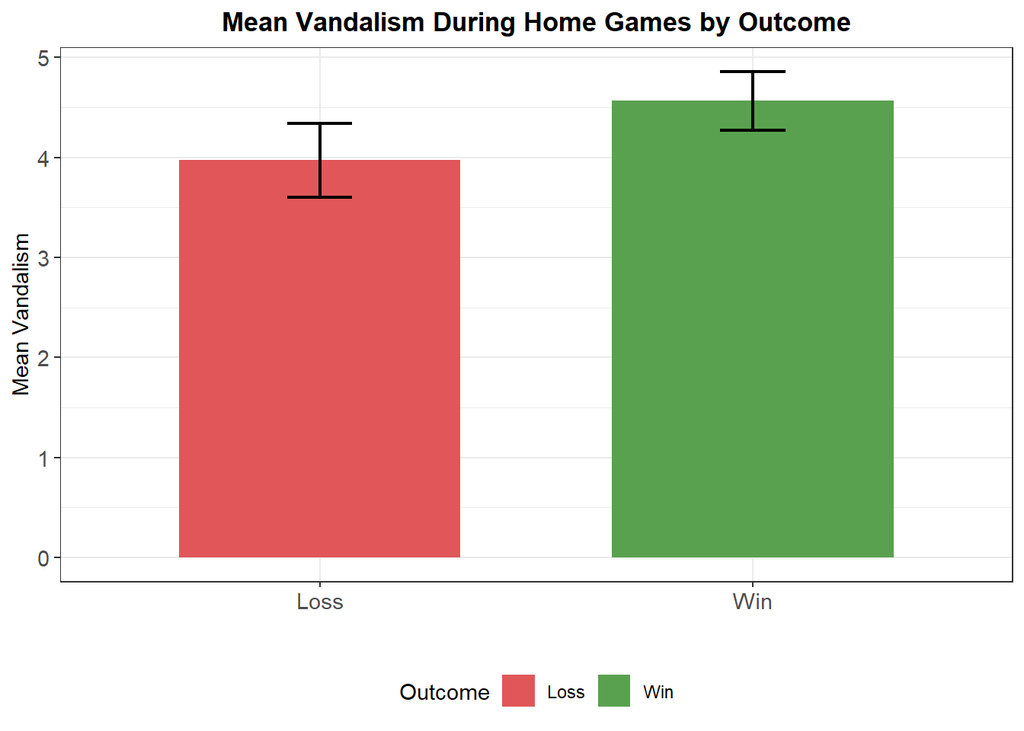

```r
ggplot(
  win_loss_summary,
  aes(x = outcome, y = mean_vandalism, fill = outcome)
) +
  geom_col(width = 0.65) +
  geom_errorbar(
    aes(
      ymin = mean_vandalism - se_vandalism,
      ymax = mean_vandalism + se_vandalism
    ),
    width = 0.15,
    linewidth = 0.8
  ) +
  scale_fill_manual(
    values = c(
      "Win" = "#59A14F",
      "Loss" = "#E15759"
    )
  ) +
  labs(
    title = "Mean Vandalism During Home Games by Outcome",
    x = "",
    y = "Mean Vandalism",
    fill = "Outcome"
  ) +
  theme_bw() +
  theme(
    plot.title = element_text(hjust = 0.5, face = "bold"),
    legend.position = "bottom",
    axis.text = element_text(size = 11)
  )
```

```r
home_only <-
  analysis_data %>%
  filter(home_game == 1)

assault_win_model <- lm(
  assault ~ home_win +
    factor(ori) +
    factor(month) +
    factor(year),
  data = home_only
)

vandalism_win_model <- lm(
  vandalism ~ home_win +
    factor(ori) +
    factor(month) +
    factor(year),
  data = home_only
)
```

```r
win_loss_results <- tibble(
  Outcome = c("Assault", "Vandalism"),
  Estimate = c(-0.060, 0.067),
  P_value = c(0.891, 0.853)
)

knitr::kable(win_loss_results)
```

| Outcome | Estimate | P_value |
| --- | --- | --- |
| Assault | -0.060 | 0.891 |
| Vandalism | 0.067 | 0.853 |

Extension: Home Wins versus Home Losses

We examined whether the outcome of a home game affected crime rates. Restricting the sample to home games, we estimated separate linear regressions of assault and vandalism counts on an indicator for whether the home team won, controlling for agency, month, and year fixed effects.

The estimated coefficient on home_win was -0.060 for assaults (p = 0.891) and 0.067 for vandalism (p = 0.853). These effects are very small and statistically insignificant, suggesting that home victories and home losses are associated with similar crime levels. Thus, our results indicate that the presence of a home game itself matters more than whether the team wins or loses.

# Conclusion

In this project, we replicated key findings from Rees and Schnepel (2010) using NIBRS crime data and college football schedules from 2000–2005. We constructed a panel of 26 college towns and examined how daily assault and vandalism counts varied depending on whether a football game was being played.

Our descriptive statistics and figures showed that both assaults and vandalism tended to be higher on home game days than on days without games, providing evidence consistent with the original study. Per-team plots revealed that the size of these effects varied across communities, with some college towns exhibiting much larger increases in crime than others.

As an extension, we investigated whether the outcome of a home game mattered. Comparing home wins and home losses, we found little evidence that the final result of the game affected assault or vandalism rates. This suggests that the increased crime associated with college football is driven more by the presence of large crowds and game-day activity than by whether the home team wins or loses.

Overall, our results support the idea that college football games are associated with increases in certain types of crime and demonstrate how publicly available data can be used to reproduce and extend findings from academic research.